# Geovisualisierung der prozentualen Verteilung der Bevölkerung im Alter ab 60 Jahren der sächsischen Wahlkreise

Janosch Püschel

## **Installation der Packages**

```r
library(sf)
library(tidyverse)
library(readxl)
library(ggplot2)
library(rgdal)
```

## **Einlesen der Strukturdaten**

```r
Strukturdaten <- read_excel("btw21_strukturdatenEXCEL.xlsx")
```

## **Reinigung des Datensatzes *Strukturdaten***

Zunächst werden werden Zeilen aus dem Datensatz *Strukturdaten* gelöscht.

```r
Strukturdaten <- Strukturdaten[-(1:7), ]
Strukturdaten <- Strukturdaten[-(2:160), ]
Strukturdaten <- Strukturdaten[-(18:158), ]
```

Anschließend werden die Spalten mit *Wahlkreisnamen*, *Alter von 60 bis 74* sowie *Alter 75 und mehr* extrahiert.

```r
Alter_data <- subset(Strukturdaten, select = c(...3, ...16, ...17))
```

Abschließend wird der Spaltenkopf abgetrennt.

```r
Alter_data <- Alter_data[-(1), ]
```

## **Erstellung der Karte**

Zunächst wird das Shapefile mit den Daten zu den Wahlkreisen in Sachsen eingelesen.

```r
wahlkreise <- "Geometrie_Wahlkreise_20DBT_geo.shp"
wahlkreise_shp <- st_read(wahlkreise)
glimpse(wahlkreise_shp)
```

```
## Rows: 299
## Columns: 5
## $ WKR_NR    <dbl> 1, 2, 3, 4, 5, 6, 7, 8, 9, 11, 12, 13, 14, 15, 16, 17, 18, 1…
## $ WKR_NAME  <chr> "Flensburg – Schleswig", "Nordfriesland – Dithmarschen Nord"…
## $ LAND_NR   <chr> "01", "01", "01", "01", "01", "01", "01", "01", "01", "01", …
## $ LAND_NAME <chr> "Schleswig-Holstein", "Schleswig-Holstein", "Schleswig-Holst…
## $ geometry  <MULTIPOLYGON [°]> MULTIPOLYGON (((9.708774 54..., MULTIPOLYGON ((…
```

Anschließend werden redundante Geodaten aus dem Shapefile *wahlkreise_shp* entfernt, um die Rohkarte mit den Geodaten der sächsischen Wahlkreise zu erstellen.

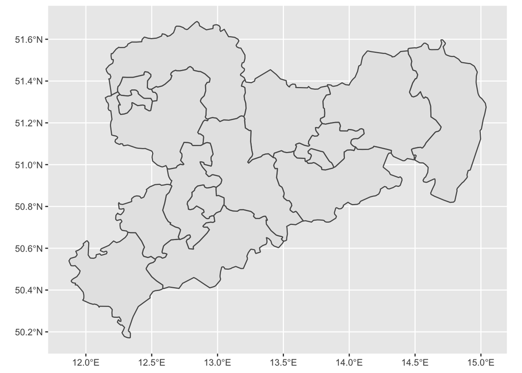

```r
wahlkreise_shp <- wahlkreise_shp[-(166:299), ]
wahlkreise_shp <- wahlkreise_shp[-(1:149), ]

wahlkreise_shp %>%
  ggplot() +
  geom_sf()
```

Die Daten der *Alter_data* werden as numeric gesetzt.

```r
Alter_data$...16 <- as.numeric(Alter_data$...16)
Alter_data$...17 <- as.numeric(Alter_data$...17)
```

Um den prozentualen Anteil der Bevölkerung im Alter ab 60 Jahren zu ermitteln, wird die Summe der Daten *Alter 60-74* und *Alter ab 75* ermittelt und anschließend dem Datensatz eine neue Spalte mit diesen Daten hinzugefügt.

```r
rowSums(Alter_data[ , c(2, 3)], na.rm=TRUE)
```

```
##  [1] 34.4 25.5 25.5 34.8 35.7 36.8 38.5 35.1 27.1 28.0 36.1 34.4 37.9 38.5 37.3
## [16] 38.6
```

```r
Alter_data$row_sum <- rowSums(Alter_data[ , c(2,3)], na.rm=TRUE)
```

Die Spaltennamen der *Alter_data* werden entsprechend der Spaltennamen der *wahlkreise_shp* angeglichen.

```r
colnames(Alter_data) <- c("WKR_NAME", "Alter_60_bis_74", "Alter_ab_75", "Alter_ab_60" )
```

Die Zeilennummerierung der *wahlkreis_shp* wird entsprechend der der *Alter_data* angeglichen.

```r
row.names(wahlkreise_shp) <- c(1, 2, 3, 4, 5, 6, 7, 8, 9, 10, 11, 12, 13 ,14 ,15 ,16)
```

Die Daten zum Alter ab 60 Jahren aus *Alter_data* werden zu *wahlkreise_shp* hinzugefügt.

```r
Alteronly <- subset(Alter_data, select=c(Alter_ab_60))
wahlkreise_shp = cbind(wahlkreise_shp, Alteronly)
```

Abschließend wird der Plot der Altermap erstellt.

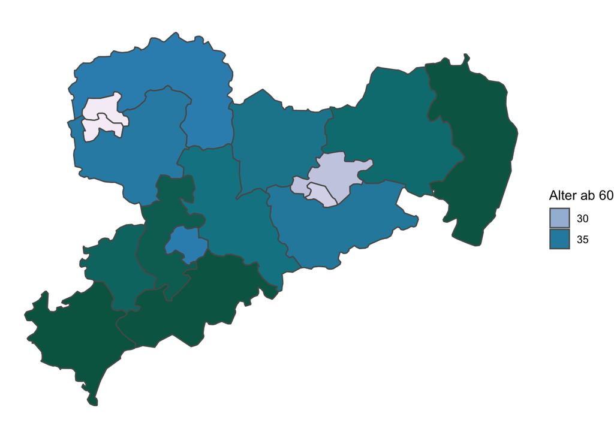

```r
ggplot(wahlkreise_shp) +
  geom_sf(aes(fill = Alter_ab_60)) -> Altermap

Altermap + scale_fill_distiller(palette = 10, direction = 1,
  guide = guide_legend(title = "Alter ab 60")) +
  theme_void()
```